# Solutions to Chapter 2 Exercises

### 2.4.1 Exercises

**1. Experiment with the colour, shape and size aesthetics. What happens when you map them to continuous values? What about categorical values? What happens when you use more than one aesthetic in a plot?**

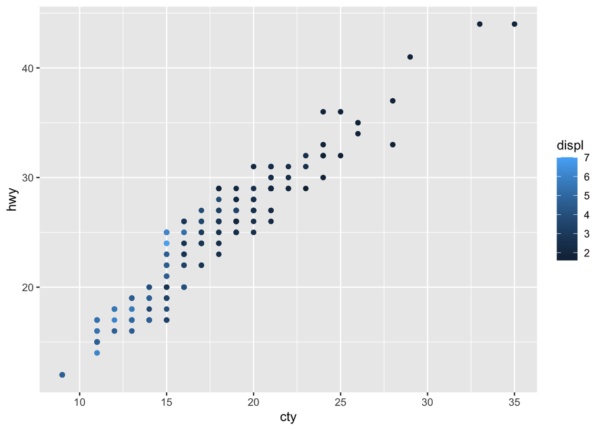

```r
# Map color to continuous value
mpg %>%
  ggplot(aes(cty, hwy, color = displ)) +
  geom_point()
```

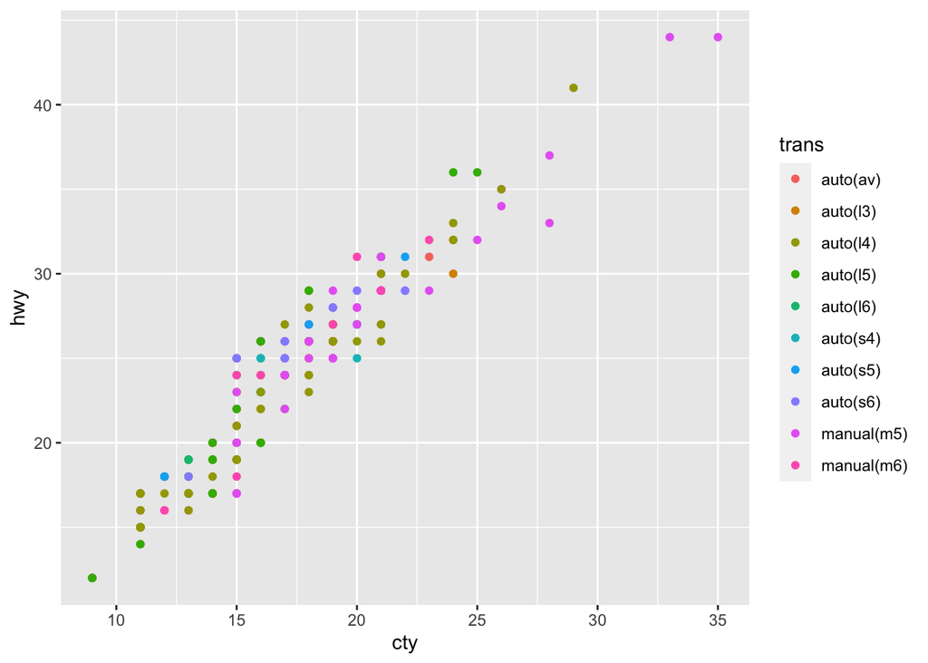

```r
# Map color to categorical value
mpg %>%
  ggplot(aes(cty, hwy, color = trans)) +
  geom_point()
```

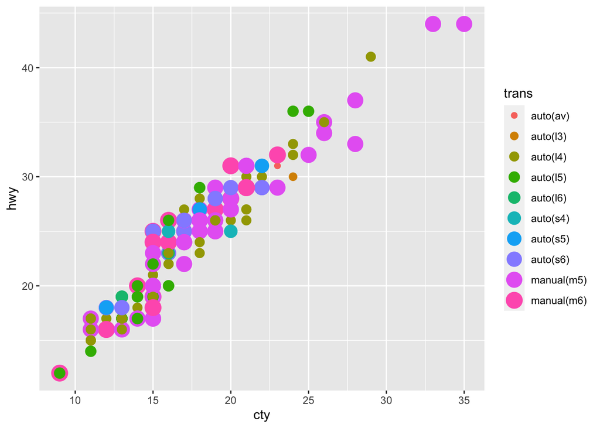

```r
# Use more than one aesthetic in a plot
mpg %>%
  ggplot(aes(cty, hwy, color = trans, size = trans)) +
  geom_point()
```

**2. What happens if you map a continuous variable to shape? Why? What happens if you map trans to shape? Why?**

```r
mpg %>%
  ggplot(aes(cty, hwy, shape = displ)) +
  geom_point()
```

- I can not map a continuous variable to shape and I get an error message: `Error: A continuous variable can not be mapped to shape`

```
## Warning: The shape palette can deal with a maximum of 6 discrete values because
## more than 6 becomes difficult to discriminate; you have 10. Consider
## specifying shapes manually if you must have them.
```

```
## Warning: Removed 96 rows containing missing values (geom_point).
```

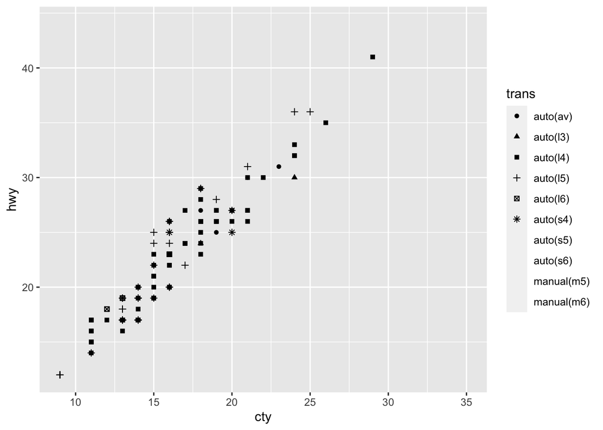

```r
mpg %>%
  ggplot(aes(cty, hwy, shape = trans)) +
  geom_point()
```

- I get an warning message that tells me the shape palette can only deal with 6 discrete values.

**3. How is drive train related to fuel economy? How is drive train related to engine size and class?**

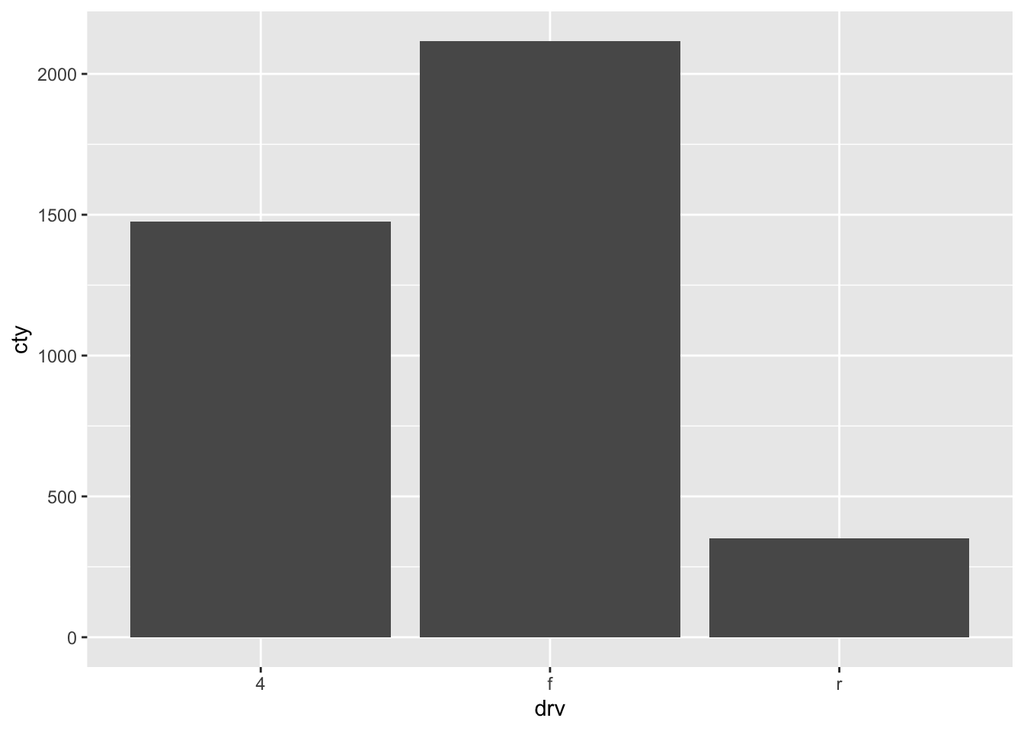

```r
mpg %>%
  ggplot(aes(drv, cty)) +
  geom_col()
```

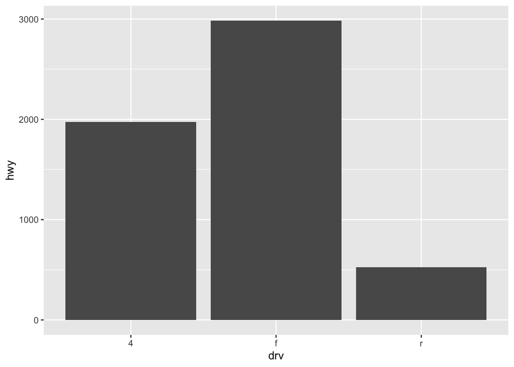

```r
mpg %>%
  ggplot(aes(drv, hwy)) +
  geom_col()
```

- Front-wheel drive has the best fuel economy, then 4wd, then rear wheel drive.

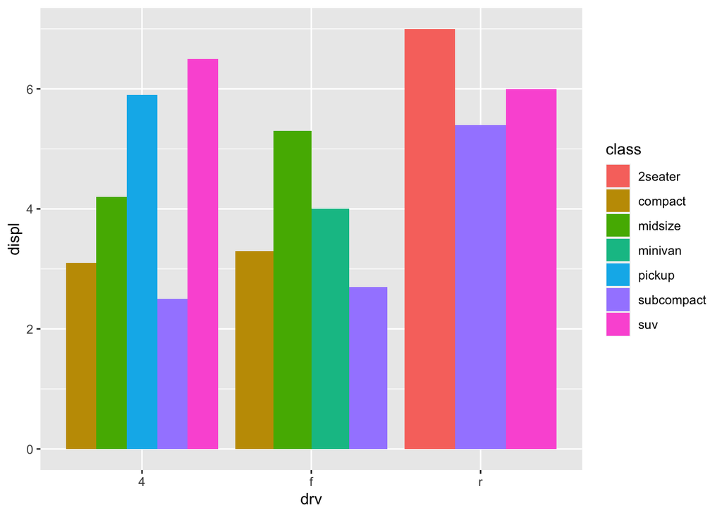

```r
mpg %>%
  ggplot(aes(drv, displ, fill = class)) +
  geom_col(position = "dodge")
```

### 2.5.1 Exercises

**1. What happens if you try to facet by a continuous variable like hwy? What about cyl? What’s the key difference?**

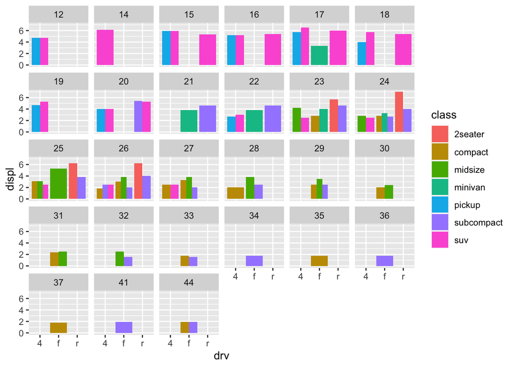

```r
mpg %>%
  ggplot(aes(drv, displ, fill = class)) +
  geom_col(position = "dodge") +
  facet_wrap(~hwy)
```

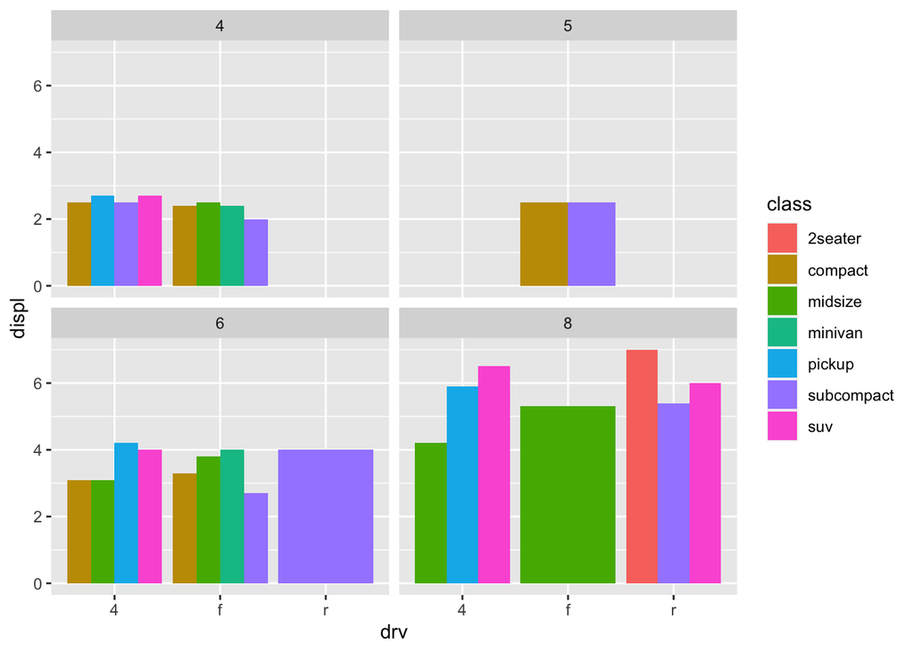

```r
mpg %>%
  ggplot(aes(drv, displ, fill = class)) +
  geom_col(position = "dodge") +
  facet_wrap(~cyl)
```

- The key difference is `hwy` is a continuous variable that has 27 unique values, so you get 27 different subsets. However, `cly` is a categorical variable and has 4 unique values, so `cyl` only has 4 different subsets. It is less cluttered when you try to facet.
- (Rademaker, 2016) Facetting by a continous variable works but becomes hard to read and interpret when the variable that we facet by has to many levels.

**2. Use faceting to explore the 3-way relationship between fuel economy, engine size, and number of cylinders. How does faceting by number of cylinders change your assessement of the relationship between engine size and fuel economy?**

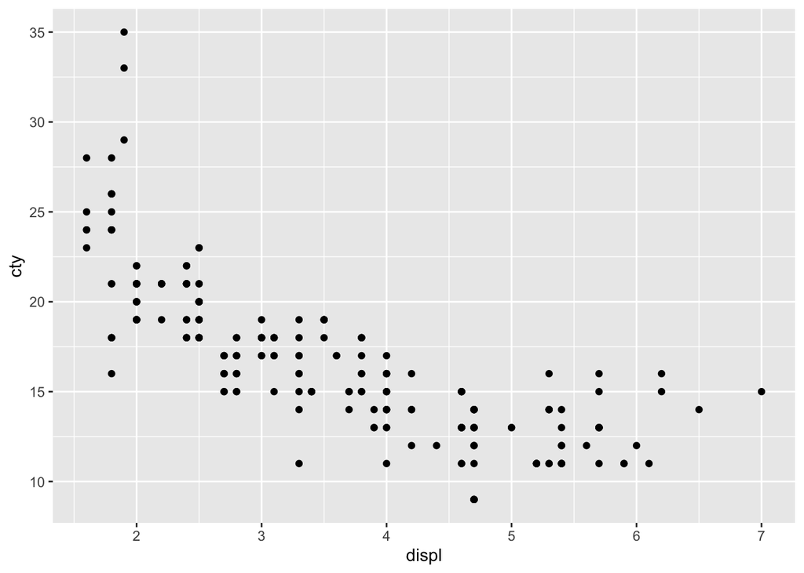

```r
mpg %>%
  ggplot(aes(displ, cty)) +
  geom_point()
```

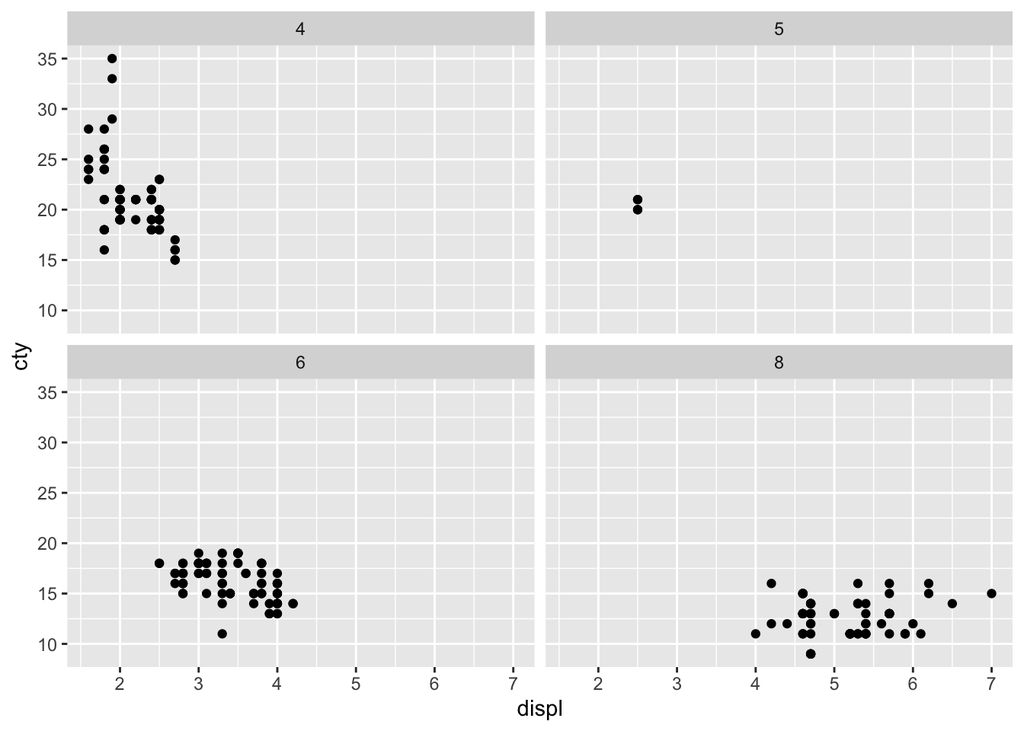

```r
mpg %>%
  ggplot(aes(displ, cty)) +
  geom_point() +
  facet_wrap(~cyl)
```

- When I initially plot engine size and fuel economy, I see an overall decreasing linear relationship. Upon faceting, I see that the decreasing relationship is mostly seen in the 4 cylinder subset. In the other cylinder subsets, we see a flat relationship - as engine displacement increases, fuel economy remains constant.

**3. Read the documentation for `facet_wrap()`. What arguments can you use to control how many rows and columns appear in the output?**

- I can use the arguments `nrow, ncol` to control how many rows and columns appear in the output.

**4. What does the `scales` argument to `facet_wrap()` do? When might you use it?**

- It allows users to decide whether scales should be fixed. I would use it whenever different subsets of the data are on vastly different scales.
- (Rademaker, 2016) If we want to compare across facets, `scales = "fixed"` is more appropriate. If our focus is on individual patterns within each facet, setting `scales = "free"` might be more approriate.